# Linear models

Instructor: Maxim Fedotov[^1]

September 2022

# Linear regression

Linear regression is a fundamental foundation of statistics. Despite its observable simplicity, it is still used widely and is an origin of more sophisticated models.

Consider a setting where you have a dataset with $n$ observations of a form $\{(y_i, \mathrm{x}_i)\}_{i=1}^{n}$ where $y_i$ is an output variable. Linear regression assumes linear dependence between the output $y$ and the vector of regressors $\mathrm{x}$ together with persistence of random noise. That is,
$$y_i = \mathrm{x}_i^T
\beta + \varepsilon_i$$
where $\beta \in \mathbb{R}^{p}$ is a vector of coefficients, $\varepsilon = (\varepsilon_1, \ldots, \varepsilon_n) \sim \mathbb{P}_\varepsilon$ is a noise vector.

The formulation can be rewritten in matrix notation:
$$y = X \beta + \varepsilon,$$
where $y \in \mathbb{R}^{n}$, $X \in \mathbb{n \times p}$ is a design matrix, $\varepsilon \in \mathbb{R}^{n}$.

# Simulating data

Let’s first generate some artificial data for which we know the ground truth. We are going to write a function which allows to create a dataset of arbitrarily many dimensions (i.e. a vector of coefficients can be of any length). We assume that the regressors come from multivariate normal distribution.

```r
sim.linmod <- function(n, b, noise.sd, rho.x = 0) {

    # How many regressors?
    p <- length(b)

  # First, define a covariance matrix (Sigma) for the regressors.
    # Note: assume that an intercept is also included in b.
  Sigma <- diag(p - 1)
  Sigma[upper.tri(Sigma)] <- Sigma[lower.tri(Sigma)] <- rho.x

  # Draw the design matrix from a multivariate normal.
    x <- rmvnorm(n = n, sigma = Sigma)

  # Then generate y as a function of x and some noise.
  # A linear model of the form: y = Xb + e;
  # use matrix multiplication operator
  y <- cbind(1, x) %*% b + rnorm(n, mean = 0, sd = noise.sd)

  # put x and y in a dataframe
  data <- data.frame(y, x)

  # rename all the x variables so that they have the following format:
  # x1, x2, ...
  names(data)[2:p] <- paste0("x", 1:(p - 1))

  return(data)
}

# lets try it out
set.seed(1234)
data <- sim.linmod(200, c(5, 3, -2), 2, 0.3)
head(data)
```

```
##           y         x1          x2
## 1 -1.088649 -1.1509832  0.09103446
## 2 11.527929  0.7159032 -2.15395689
## 3  4.529436  0.5009523  0.56531759
## 4  2.503199 -0.6510388 -0.62752183
## 5  5.686707 -0.6929845 -0.96538910
## 6  5.555835 -0.6231786 -1.05924053
```

```r
# output should be:
#           y         x1          x2
# 1 -1.088649 -1.1509832  0.09103446
# 2 11.527929  0.7159032 -2.15395689
# 3  4.529436  0.5009523  0.56531759
# 4  2.503199 -0.6510388 -0.62752183
# 5  5.686707 -0.6929845 -0.96538910
# 6  5.555835 -0.6231786 -1.05924053
# ...
```

# Illustrate the data

We will first generate the data of lower dimension that can be easily visualized. We will use this data for the rest of the exercise.

```r
set.seed(1234)
trainData <- sim.linmod(200, c(5, 3), 2)
head(trainData)
```

```
##            y         x1
## 1  2.3492564 -1.2070657
## 2  7.2258253  0.2774292
## 3  8.6243514  1.0844412
## 4 -0.6356261 -2.3456977
## 5  6.9107361  0.4291247
## 6  8.0390924  0.5060559
```

```r
# output should be:
#            y         x1
# 1  2.3492564 -1.2070657
# 2  7.2258253  0.2774292
# 3  8.6243514  1.0844412
# 4 -0.6356261 -2.3456977
# 5  6.9107361  0.4291247
# 6  8.0390924  0.5060559
# ...
```

Use the `ggplot2` package to create a nicely formatted scatter plot of the data.

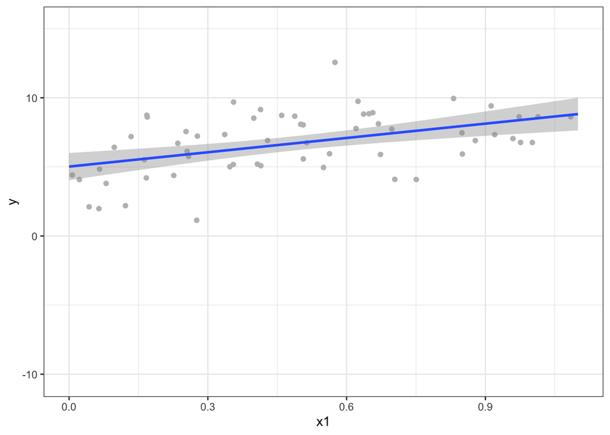

```r
library(ggplot2)
# generate the figure
figure <- ggplot(trainData, aes(x1, y))+
  geom_point(shape = 19, colour = 'gray')+
  geom_smooth(method = lm, formula = y ~ x, se = TRUE, fullrange = T)+
  scale_x_continuous(limits = c(0, 1.1))+
  theme_bw()

# show the figure in the report
print(figure)
```

# Fitting linear models

The classic estimator of the linear regression model is the ordinary least squares estimator, defined as the minimizer of the residual sum of squares

$$\hat{\beta} = \textrm{argmin}_{\beta} (y
- X\beta)^T (y - X\beta).$$

The estimator has a closed form solution whenever $X^TX$ is invertible.

$$\hat{\beta} = (X^T X)^{-1} X^T
y.$$
Although, it is worth mentioning that properties of this estimator depends on different conditions (e.g. see Gauss–Markov theorem).

You will use this estimator to compute the regression weights in your `linearmodel` function. It should produce the same coefficients as the `lm` function built-in R. But before that, use the `lm` function and fit a linear model to the data.

```r
# regress y on x
lmfit <- lm(y ~ x1, data = trainData)

# use the "summary" command on results to get a more detailed overview of the
# fit, you will get additional info like standard errors
summary(lmfit)
```

```
##
## Call:
## lm(formula = y ~ x1, data = trainData)
##
## Residuals:
##     Min      1Q  Median      3Q     Max
## -6.3532 -1.3936  0.1024  1.3172  5.5594
##
## Coefficients:
##             Estimate Std. Error t value Pr(>|t|)
## (Intercept)   5.1586     0.1422   36.28   <2e-16 ***
## x1            3.2092     0.1394   23.02   <2e-16 ***
## ---
## Signif. codes:  0 '***' 0.001 '**' 0.01 '*' 0.05 '.' 0.1 ' ' 1
##
## Residual standard error: 2.008 on 198 degrees of freedom
## Multiple R-squared:  0.7279, Adjusted R-squared:  0.7265
## F-statistic: 529.7 on 1 and 198 DF,  p-value: < 2.2e-16
```

```r
# extract the coefficients with SE's, t-statistics and p-values
# note that this is a matrix so we can extract anything we like from here
print(summary(lmfit)$coef)
```

```
##             Estimate Std. Error  t value     Pr(>|t|)
## (Intercept) 5.158584  0.1421965 36.27786 2.080665e-89
## x1          3.209236  0.1394427 23.01472 7.229516e-58
```

Let’s obtain diagnostic plots by using plot command on the output of the lm function (again, example of overloading the functions)

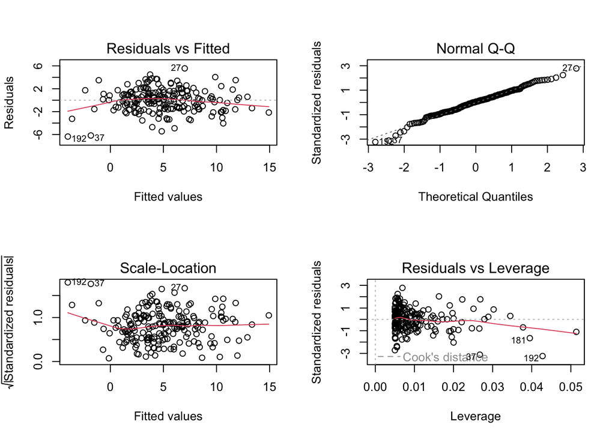

```r
par(mfrow = c(2, 2))
plot(lmfit)
```

```r
par(mfrow = c(1, 1))
```

Obtain predictions for the training data based on the fitted model

```r
trainPredictions <- fitted(lmfit)
head(trainPredictions)
```

```
##         1         2         3         4         5         6
##  1.284825  6.048920  8.638811 -2.369313  6.535746  6.782636
```

and compute the mean square error between predictions and true values, y

```r
trainMSE <- mean((trainPredictions - trainData$y)^2)
trainMSE
```

```
## [1] 3.990684
```

How do you know how good is this? Compute now a mean square error for the base model - a simple mean of the observed y values

```r
baseMSE <- mean((mean(trainData$y) - trainData$y)^2)
baseMSE
```

```
## [1] 14.66632
```

```r
set.seed(4321)
testData <- sim.linmod(100, c(5, 3), 2)
head(testData)
```

```
##           y         x1
## 1  5.329033 -0.4267574
## 2  5.415174 -0.2236118
## 3  5.480114  0.7176068
## 4  7.018580  0.8414457
## 5  7.421491 -0.1283573
## 6 10.314894  1.6093472
```

and verify how our model predicts on it

```r
testPredictions <- predict(lmfit, testData)
head(testPredictions)
```

```
##         1         2         3         4         5         6
##  3.789019  4.440961  7.461553  7.858981  4.746655 10.323358
```

```r
# compute the mean square error between predictions and true values, y
testMSE <- mean((testPredictions - testData$y)^2)
testMSE
```

```
## [1] 3.520773
```

```r
# and benchmark against MSE of just the sample mean of the training set
test_baseMSE <- mean((mean(trainData$y) - testData$y)^2 )
test_baseMSE
```

```
## [1] 11.98646
```

Extra: next, fit the linear model on the trainData this time don’t include the intercept in the model and include an additional variable that is a square root of absolute value of X.

```r
lmfit2 <-lm(y ~ x1 + sqrt(abs(x1)) - 1, data = trainData)
lmfit2
```

```
##
## Call:
## lm(formula = y ~ x1 + sqrt(abs(x1)) - 1, data = trainData)
##
## Coefficients:
##            x1  sqrt(abs(x1))
##         3.056          5.182
```

```r
summary(lmfit2)
```

```
##
## Call:
## lm(formula = y ~ x1 + sqrt(abs(x1)) - 1, data = trainData)
##
## Residuals:
##      Min       1Q   Median       3Q      Max
## -10.3899  -0.9946   1.0098   2.8956   6.8776
##
## Coefficients:
##               Estimate Std. Error t value Pr(>|t|)
## x1              3.0558     0.2078   14.70   <2e-16 ***
## sqrt(abs(x1))   5.1820     0.2360   21.96   <2e-16 ***
## ---
## Signif. codes:  0 '***' 0.001 '**' 0.01 '*' 0.05 '.' 0.1 ' ' 1
##
## Residual standard error: 2.996 on 198 degrees of freedom
## Multiple R-squared:  0.7745, Adjusted R-squared:  0.7722
## F-statistic:   340 on 2 and 198 DF,  p-value: < 2.2e-16
```

## Custom function to compute coefficients of a linear model (OLS).

Now we will define our own function for fitting linear models, `linearmodel` function, that will use the closed form solution of least squares estimator to compute the weights.

$$\hat{\beta} = (X^T X)^{-1} X^T
y.$$

```r
linearmodel <- function(data, intercept = TRUE) {

    # we will assume that first column is the response variable
    # an all others are having a form: x1, x2, ...

    # number of features
    m <- ncol(data) - 1

    # first we need to add a vector of 1's to our x (intercept),
    # if instructed by the intercept argument
    if (intercept) {
        X <- cbind(1, as.matrix(data[, 2:(m + 1)]))
    } else {
        X <- as.matrix(data[, 2:(m + 1)])
    }
    y <- data$y

    # now implement the analytical solution
    # using the matrix operations
    # hint: check "solve" command
    bhat <- solve(t(X) %*% X) %*% t(X) %*% y

    # compute the predictions for the training data, i.e. fitted values
    yhat <- X %*% bhat

    # compute the mean square error for the training data, between y and yhat
    MSE <- mean((yhat - y)**2)

    return(list(coef = bhat, predictions = yhat, MSE = MSE))
}

# check out the function
lmmefit <- linearmodel(trainData)
lmmefit$coef
```

```
##          [,1]
## [1,] 5.158584
## [2,] 3.209236
```

```r
# compare it to the output of the lm function
coefficients(lmfit)
```

```
## (Intercept)          x1
##    5.158584    3.209236
```

# Illustrate the data and your model predictions

We will now create a plot where we illustrate our predictions.

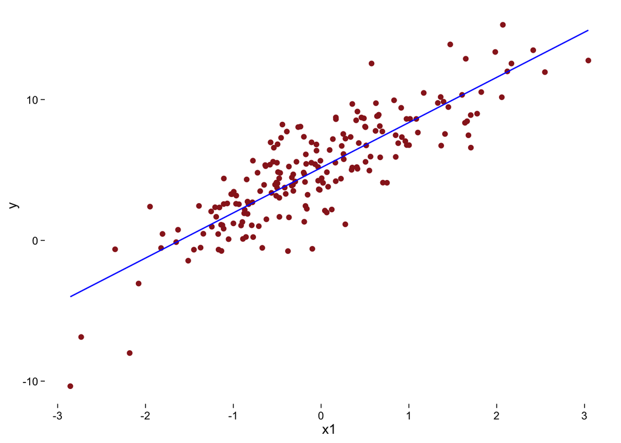

```r
# first create an additional data frame with x1 variable from trainData as one
# column and predictions from the model, yhat, as a second model
predData <- data.frame(x1 = trainData$x1, yhat = lmmefit$predictions)

# generate the figure
figure <-
    ggplot(trainData, aes(y = y, x = x1)) +
    geom_point(size = 1.5, color = "#992121") +

    # you will need to use geom_line, but now with
    # predData, to illustrate the linearmodel fit
    geom_line(data = predData, aes(x = x1, y = yhat),
              color = "blue") +

    theme(
        panel.grid.major = element_blank(),
        panel.grid.minor = element_blank(),
        panel.border = element_blank(),
        panel.background = element_blank(),
        axis.line.x = element_blank(),
        axis.line.y = element_blank(),
        axis.ticks = element_line(lineend = 4, linetype = 1,
                                  colour = "black", size = 0.3),
        axis.text = element_text(colour = "black"),
        axis.text.x = element_text(vjust = 0.5),
        validate = TRUE
    )

# show the figure in the report
print(figure)
```

[^1]: This handout is a re-adaptation of part of Jordi Llorens’s materials who was teaching this brushup in the previous years. The original licence is located [here](https://github.com/Jordi-Llorens/r-tutorial/blob/master/LICENSE).